# Your First Dashboard

flexdashboard: one map, one time series, one file

Author

Eric M. Delmelle · Lehigh University

## Today

Today you build **Milestone M1**. Reading: **Moraga Ch. 12**.

> **M1 — Static dashboard** A `flexdashboard` that loads your data and displays at least one map and one time series, deployed or renderable from your repository.

Nothing in M1 is new. You have made `leaflet` maps since Exercise 4 and `ggplot2` charts since the first week. A dashboard only puts them **side by side on one screen**. We build one together on lung cancer in Ohio, then you swap in your own data.

| M1 asks for | Where it is today |
| --- | --- |
| a `flexdashboard` | §2, one file and three symbols |
| loads your data | §3.1 and §4 |
| at least one map | §3.2 |
| at least one time series | §3.3 |
| renderable from your repository | §3.6 |
| deployed (optional) | §3.7 |

Install the three new packages once, in the **Console**:

```r
install.packages(c("flexdashboard", "plotly", "DT"))
```

# 1 What a dashboard is

A report scrolls: you read it top to bottom, once. A dashboard fits **one screen**, and each panel answers one question about the same data. In ours, the map answers *where*, the time series *when*, and the table *which county, exactly*. The reader looks at all three at once.

# 2 One file, three symbols

A `flexdashboard` is an R Markdown file (`.Rmd`) with one line in its YAML header. The layout is written with three symbols:

| You type | You get |
| --- | --- |
| `output: flexdashboard::flex_dashboard` | a dashboard instead of a report |
| `Column {data-width=600}`, then a line of dashes `-----` | a new column; widths are relative |
| `### Title` | a panel, with its title |
| an R chunk under `###` | what the panel shows |
| `> text` under the chunk | a small note at the bottom of the panel |

This skeleton:

````markdown
---
title: "Lung cancer in Ohio, 1968--1988"
output: flexdashboard::flex_dashboard
---

```{r setup, include=FALSE}
# packages and data: runs once, shows nothing
```

Column {data-width=600}
-----------------------------------------------------------------------

### Map

Column {data-width=400}
-----------------------------------------------------------------------

### Time series

### Table
````

gives this screen:

title: Lung cancer in Ohio, 1968–1988

### Map  
Column {data-width=600}

### Time series  
Column {data-width=400}

### Table

Two columns; the second holds two panels stacked. This is exactly Moraga’s PM<sub>2.5</sub> dashboard (Ch. 12), with a time series in place of the histogram.

**NoteWhy `.Rmd` and not `.qmd`?**

`flexdashboard` is an R Markdown format, and Moraga Ch. 12–15 build on it. For M2 we add Shiny to this same file with one line in the YAML header. So the dashboard is the one `.Rmd` file in your repository; everything else stays `.qmd`.

# 3 Worked example: lung cancer in Ohio

The data of Moraga Ch. 7: lung cancer cases in the 88 counties of Ohio, every year from 1968 to 1988. One row per county and year:

| Column | Meaning |
| --- | --- |
| `GEOID` | county FIPS code, to join with the boundaries |
| `county` | county name |
| `year` | 1968, …, 1988 |
| `Y` | observed cases |
| `E` | expected cases (indirect standardization, by age and sex) |
| `population` | population at risk |

Save the CSV in your `data/` folder, as in Exercises 4–7.

## 3.1 Load and summarise the data

This chunk goes at the top of the dashboard, before the first column. It runs once and shows nothing; every panel can use what it creates.

```r
library(sf)
library(dplyr)
library(readr)
library(ggplot2)
library(plotly)
library(leaflet)
library(DT)
library(tigris)
options(tigris_use_cache = TRUE)

# data: one row per county and year
oh <- read_csv("data/ohio_lung_cancer_1968_1988.csv",
               col_types = cols(GEOID = "c"))          # GEOID as text

# boundaries
oh_map <- counties(state = "OH", cb = TRUE, year = 2020,
                   progress_bar = FALSE) |>
  st_transform(4326)                             # leaflet wants lon/lat

# for the map: one row per county
by_county <- oh |>
  group_by(GEOID) |>
  summarise(Y = sum(Y), E = sum(E), .groups = "drop") |>
  mutate(SIR = Y / E)

oh_map <- left_join(oh_map, by_county, by = "GEOID")

# for the time series: one row per year
focus <- "Cuyahoga"                              # county to follow

by_year <- bind_rows(
  oh |> group_by(year) |>
    summarise(Y = sum(Y), E = sum(E), .groups = "drop") |>
    mutate(area = "Ohio"),
  oh |> filter(county == focus) |>
    mutate(area = focus)
) |>
  mutate(SIR = Y / E)
```

The same data, **summarised twice**: over the years for the map (`by_county`, 88 rows), and over the counties for the time series (`by_year`, one row per year for Ohio and one per year for Cuyahoga County). That is the whole idea of M1.

Check the join before going further: the number of counties without data should be zero.

```r
sum(is.na(oh_map$SIR))                                 # should be 0
```

```
[1] 0
```

## 3.2 The map

The leaflet map of Exercise 4: the SIR, with the same classes and the same red–blue colours, so that the neutral class sits around 1.

```r
breaks <- c(0, 0.5, 2/3, 0.9, 1/0.9, 1.5, 2, Inf)  # Exercise 4 classes
pal <- colorBin(rev(RColorBrewer::brewer.pal(7, "RdBu")),
                domain = oh_map$SIR, bins = breaks)

leaflet(oh_map) |>
  addTiles() |>
  addPolygons(
    fillColor = ~pal(SIR), fillOpacity = 0.8,
    color = "white", weight = 1,
    label = ~sprintf("%s: SIR %.2f (%.0f observed, %.0f expected)",
                     NAME, SIR, Y, E),
    highlightOptions = highlightOptions(weight = 2, color = "black",
                                        bringToFront = TRUE)
  ) |>
  addLegend("bottomright", pal = pal, values = ~SIR, title = "SIR",
            labFormat = labelFormat(digits = 2), opacity = 0.8)
```

[interactive chart not shown]

Hover over a county: the label gives its observed and expected cases, so the reader can judge whether a dark colour rests on many cases or on a handful.

## 3.3 The time series

An ordinary `ggplot`: one line for Ohio, one for Cuyahoga County, and a dashed line at 1, as many cases as expected.

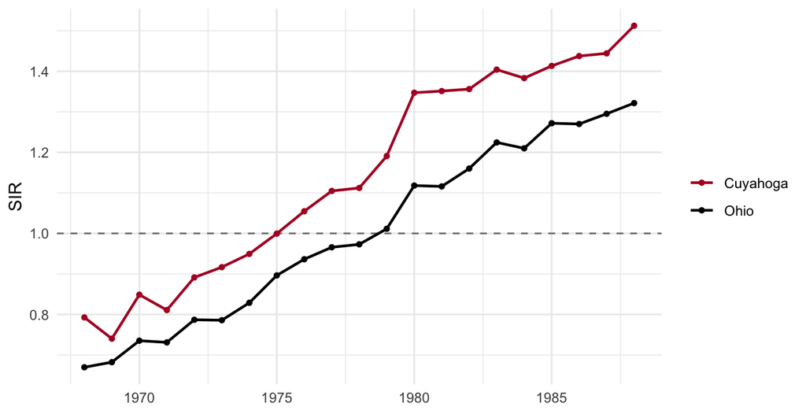

```r
cols <- setNames(c("black", "#B2182B"), c("Ohio", focus))

p <- ggplot(by_year, aes(year, SIR, colour = area)) +
  geom_hline(yintercept = 1, linetype = 2, colour = "grey50") +
  geom_line(linewidth = 0.8) +
  geom_point(size = 1.2) +
  scale_colour_manual(values = cols) +
  labs(x = NULL, y = "SIR", colour = NULL) +
  theme_minimal()

p
```

One more line makes it interactive: hover for the values, drag to zoom, double-click to reset.

```r
ggplotly(p)                                  # hover, zoom
```

[interactive chart not shown]

Ohio’s SIR rose from 0.67 in 1968 to 1.32 in 1988. The expected cases use one set of rates for the whole period, so the map averages over this rise; in M2 the reader will pick the year.

## 3.4 The table (optional)

Not required for M1, but it costs four lines and gives the exact numbers behind the colours. Click a column header to sort.

```r
oh_map |>
  st_drop_geometry() |>
  transmute(County = NAME, Observed = Y,
            Expected = round(E, 1), SIR = round(SIR, 2)) |>
  arrange(desc(SIR)) |>
  datatable(rownames = FALSE, options = list(pageLength = 10))
```

| County | Observed | Expected | SIR |
| --- | --- | --- | --- |
| Jefferson | 1124 | 872.9 | 1.29 |
| Harrison | 209 | 164.3 | 1.27 |
| Hamilton | 10603 | 8522.9 | 1.24 |
| Muskingum | 958 | 781.2 | 1.23 |
| Belmont | 944 | 771.1 | 1.22 |
| Jackson | 340 | 280.6 | 1.21 |
| Scioto | 947 | 783.1 | 1.21 |
| Meigs | 258 | 214.2 | 1.2 |
| Highland | 373 | 311.5 | 1.2 |
| Lawrence | 688 | 584.7 | 1.18 |

[output cut: 78 more lines]

## 3.5 Put it together

Paste the chunks of §3.1–§3.4 under their `###` panels. Two additions to the YAML header: `theme: cosmo`, the look of our course pages, and `source_code: embed`, a **Source Code** button in the corner, so that I can read your code from the dashboard itself. The whole file:

````markdown
---
title: "Lung cancer in Ohio, 1968--1988"
output:
  flexdashboard::flex_dashboard:
    orientation: columns
    vertical_layout: fill
    theme: cosmo
    source_code: embed
---

```{r setup, include=FALSE}
library(flexdashboard)
library(sf)
library(dplyr)
library(readr)
library(ggplot2)
library(plotly)
library(leaflet)
library(DT)
library(tigris)
options(tigris_use_cache = TRUE)
knitr::opts_chunk$set(echo = FALSE, warning = FALSE, message = FALSE)

# data: one row per county and year
oh <- read_csv("data/ohio_lung_cancer_1968_1988.csv",
               col_types = cols(GEOID = "c"))          # GEOID as text

# boundaries
oh_map <- counties(state = "OH", cb = TRUE, year = 2020,
                   progress_bar = FALSE) |>
  st_transform(4326)                             # leaflet wants lon/lat

# for the map: one row per county
by_county <- oh |>
  group_by(GEOID) |>
  summarise(Y = sum(Y), E = sum(E), .groups = "drop") |>
  mutate(SIR = Y / E)

oh_map <- left_join(oh_map, by_county, by = "GEOID")

# for the time series: one row per year
focus <- "Cuyahoga"                              # county to follow

by_year <- bind_rows(
  oh |> group_by(year) |>
    summarise(Y = sum(Y), E = sum(E), .groups = "drop") |>
    mutate(area = "Ohio"),
  oh |> filter(county == focus) |>
    mutate(area = focus)
) |>
  mutate(SIR = Y / E)
```

Column {data-width=600}
-----------------------------------------------------------------------

### Standardized incidence ratio (SIR) by county, 1968--1988

```{r map}
breaks <- c(0, 0.5, 2/3, 0.9, 1/0.9, 1.5, 2, Inf)  # Exercise 4 classes
pal <- colorBin(rev(RColorBrewer::brewer.pal(7, "RdBu")),
                domain = oh_map$SIR, bins = breaks)

leaflet(oh_map) |>
  addProviderTiles("CartoDB.Positron") |>
  addPolygons(
    fillColor = ~pal(SIR), fillOpacity = 0.8,
    color = "white", weight = 1,
    label = ~sprintf("%s: SIR %.2f (%.0f observed, %.0f expected)",
                     NAME, SIR, Y, E),
    highlightOptions = highlightOptions(weight = 2, color = "black",
                                        bringToFront = TRUE)
  ) |>
  addLegend("bottomright", pal = pal, values = ~SIR, title = "SIR",
            labFormat = labelFormat(digits = 2), opacity = 0.8)
```

> SIR = observed / expected. Red: more cases than expected; blue: fewer.

Column {data-width=400}
-----------------------------------------------------------------------

### SIR by year (dashed line: as many cases as expected)

```{r timeseries}
cols <- setNames(c("black", "#B2182B"), c("Ohio", focus))

p <- ggplot(by_year, aes(year, SIR, colour = area)) +
  geom_hline(yintercept = 1, linetype = 2, colour = "grey50") +
  geom_line(linewidth = 0.8) +
  geom_point(size = 1.2) +
  scale_colour_manual(values = cols) +
  labs(x = NULL, y = "SIR", colour = NULL) +
  theme_minimal()

ggplotly(p)                                  # hover, zoom
```

### Counties

```{r table}
oh_map |>
  st_drop_geometry() |>
  transmute(County = NAME, Observed = Y,
            Expected = round(E, 1), SIR = round(SIR, 2)) |>
  arrange(desc(SIR)) |>
  datatable(rownames = FALSE, options = list(pageLength = 10))
```

> Data: Moraga (2019), Ch. 7. Boundaries: US Census Bureau, via `tigris`.
````

## 3.6 Render it

Save the file as **`dashboard.Rmd`** at the top of your repository, next to the `data/` folder, and click **Knit** in RStudio (or run `rmarkdown::render("dashboard.Rmd")` in the Console). You get `dashboard.html`: one self-contained file that opens in any browser.

**WarningKnit, not `quarto render`**

Quarto does not know the `flexdashboard` format. Rendered with Quarto, the file comes out as an ordinary scrolling page, with the panel titles as headings. If your “dashboard” scrolls like a report, this is why.

That is M1: **renderable from your repository**.

## 3.7 Put it online (optional for M1)

Your exercises are a Quarto website published from `docs/`. Two entries in `_quarto.yml` add the dashboard to it:

```yaml
project:
  type: website
  output-dir: docs
  render:
    - "*.qmd"          # Quarto renders the .qmd pages only
  resources:
    - dashboard.html   # and copies the knitted dashboard into docs/
```

Then, each time: **Knit** `dashboard.Rmd`, run `quarto render`, and commit and push with GitHub Desktop. The dashboard is at `https://<username>.github.io/<repository>/dashboard.html`. Add a link to it from `index.qmd`:

```markdown
[My dashboard](dashboard.html)
```

# 4 Your turn: from Ohio to your data

Copy `dashboard.Rmd`, keep the layout, and change only the setup chunk:

| In the example | For your data |
| --- | --- |
| `read_csv("data/ohio_lung_cancer_1968_1988.csv", ...)` | your file, in `data/` |
| `col_types = cols(GEOID = "c")` | your ID column, as text; pad lost zeros with `sprintf("%05d", ...)` as in Exercise 4 |
| `counties(state = "OH", ...)` | your state; `tracts()` or `zctas()` for other units |
| `Y`, `E` | your observed and expected counts |
| `year` | your time column; months or weeks work as a `Date` |
| `focus <- "Cuyahoga"` | one area of your data |

**TipNo expected counts?**

Map a rate instead, with a sequential palette, since a rate has no neutral value:

```r
by_county <- mutate(by_county, rate = 1e5 * cases / population)   # per 100,000
pal <- colorQuantile("YlOrRd", by_county$rate, n = 5)              # quintiles
# then, in addPolygons(): fillColor = ~pal(rate)
```

Point data (case or facility locations): `addCircleMarkers()` in place of `addPolygons()`, with a time series of counts per period.

# 5 Before you demonstrate M1

1. **Session > Restart R**, then **Knit**: it renders from a clean start.
2. The data are read with a relative path, `data/...`, never `C:/Users/...`.
3. The map has a legend, and its title says what, where and when.
4. The time series has a labelled axis, with units.
5. A `>` note under a panel names the data source.

# 6 When it breaks

| What you see | Likely cause | Fix |
| --- | --- | --- |
| A scrolling page, not a dashboard | rendered with `quarto render`, or saved as `.qmd` | save as `.Rmd`, click **Knit** |
| `object 'oh' not found` in a panel | data loaded below the first `Column` | setup chunk first, before any `Column` |
| A grey map | the join failed: all SIRs are `NA` | `GEOID` as text; `sum(is.na(oh_map$SIR))` |
| Warning: *not long-lat data* | no `st_transform(4326)` | add it after `counties()` |
| `there is no package called 'flexdashboard'` | not installed | `install.packages(c("flexdashboard", "plotly", "DT"))` |
| Squashed panels | too many panels in one column | fewer panels, or `vertical_layout: scroll` |
| Knits, but not on GitHub Pages | `dashboard.html` not copied to `docs/` | check `resources:`, rerun `quarto render`, push |

If Knit fails on your laptop, use a lab machine or [Posit Cloud](https://posit.cloud): renderable from your repository is enough for M1.

# Next: M2

The same file. One line in the YAML header, `runtime: shiny`, and `focus` becomes a dropdown, the period a slider (Moraga Ch. 13–14).

# References

Aden-Buie, G., Sievert, C., Iannone, R., Allaire, J. J., & Borges, B. (2023). *flexdashboard: R Markdown format for flexible dashboards*. https://pkgs.rstudio.com/flexdashboard/

Moraga, P. (2019). *Geospatial health data: Modeling and visualization with R-INLA and Shiny*. Chapman & Hall/CRC, Ch. 7 and 12.